# Manova in-class Assignment

Sanjay Chhetri

11/15/2021

## QN1

Based on the relationship between the two DVs, would a MANOVA appear to be appropriate? Why or why not?

```r
survey <- read_csv("survey.csv")
head(survey)
```

```
## # A tibble: 6 x 104
##      id   sex   age age_group marital child  educ source smoke smokenum   op1
##   <dbl> <dbl> <dbl>     <dbl>   <dbl> <dbl> <dbl>  <dbl> <dbl>    <dbl> <dbl>
## 1   415     1    24         0       4     1     5      7     0       NA     3
## 2     9     0    39         1       3     1     5      1     1        2     2
## 3   425     1    48         1       4     1     2      4     0       NA     3
## 4   307     0    41         1       5     1     2      1     0        0     3
## 5   440     0    23         0       1     0     5      1     0        0     3
## 6   484     1    31         1       4     1     5      7     0       NA     2
## # ... with 93 more variables: Rop2 <dbl>, op3 <dbl>, Rop4 <dbl>, op5 <dbl>,
## #   Rop6 <dbl>, Rmast1 <dbl>, mast2 <dbl>, Rmast3 <dbl>, Rmast4 <dbl>,
## #   mast5 <dbl>, Rmast6 <dbl>, Rmast7 <dbl>, pn1 <dbl>, pn2 <dbl>, pn3 <dbl>,
## #   pn4 <dbl>, pn5 <dbl>, pn6 <dbl>, pn7 <dbl>, pn8 <dbl>, pn9 <dbl>,
## #   pn10 <dbl>, pn11 <dbl>, pn12 <dbl>, pn13 <dbl>, pn14 <dbl>, pn15 <dbl>,
## #   pn16 <dbl>, pn17 <dbl>, pn18 <dbl>, pn19 <dbl>, pn20 <dbl>, lifsat1 <dbl>,
## #   lifsat2 <dbl>, lifsat3 <dbl>, lifsat4 <dbl>, lifsat5 <dbl>, pss1 <dbl>, ...
```

```r
cor.test(survey$Mnegaff, survey$Mpstress)
```

```
##
##  Pearson's product-moment correlation
##
## data:  survey$Mnegaff and survey$Mpstress
## t = 18.969, df = 431, p-value < 2.2e-16
## alternative hypothesis: true correlation is not equal to 0
## 95 percent confidence interval:
##  0.6196883 0.7228244
## sample estimates:
##       cor
## 0.6745344
```

Since the DV’s are significantly and rather strongly correlated, combining the two DV’s to do a MANOVA makes sense. ## QN2 Did the data meet the assumption of homogeneity of variance (e.g., Levene’s test) for the two DVs? Why or why not?

```r
library(car)
survey$age_group <- factor(survey$age_group)
leveneTest(survey$Mnegaff~ survey$age_group)
```

```
## Levene's Test for Homogeneity of Variance (center = median)
##        Df F value Pr(>F)
## group   2  1.2556 0.2859
##       433
```

```r
leveneTest(survey$Mpstress~ survey$age_group)
```

```
## Levene's Test for Homogeneity of Variance (center = median)
##        Df F value Pr(>F)
## group   2  1.6036 0.2024
##       430
```

Since Levene’s tests on both DV’s returned not significant, we can be confident that homogeniety of variance is upheld.

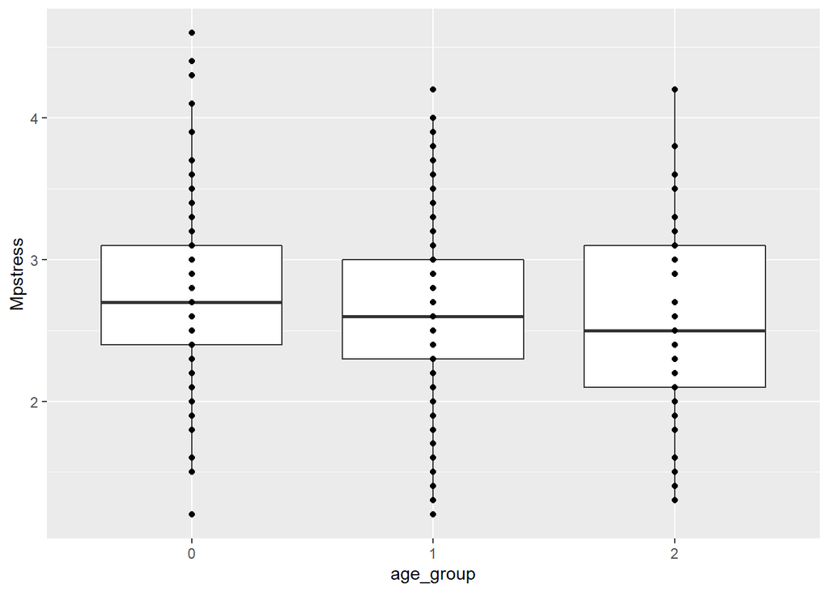

```r
survey %>% ggplot(aes(x = age_group, y = Mpstress)) +
  geom_boxplot()+
  geom_point()
```

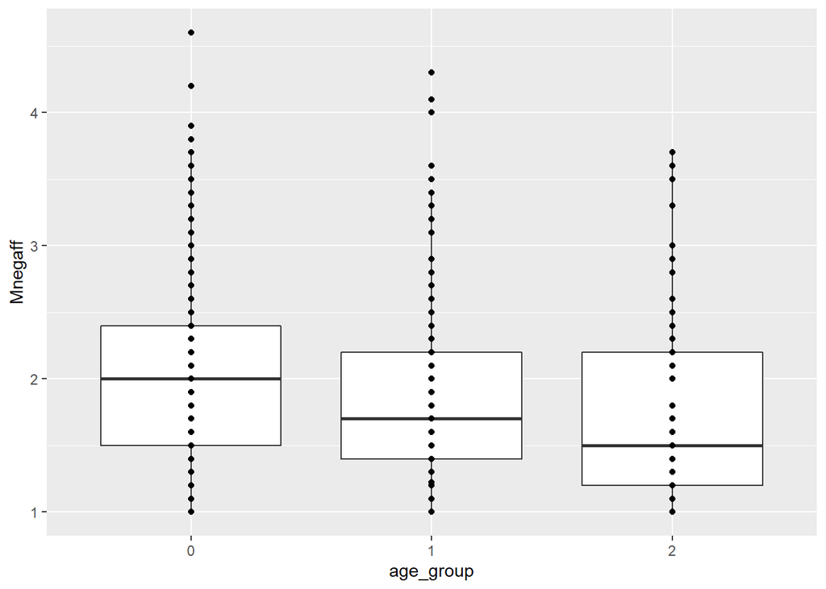

```r
survey %>% ggplot(aes(x = age_group, y = Mnegaff)) +
  geom_boxplot()+
  geom_point()
```

##Q3 Did the data meet the assumption of homogeneity of covariance (e.g., Box’s M)? Why or why not?

```r
library(heplots)
boxM(Y=survey[, c("Mpstress", "Mnegaff")], group = survey$age_group)
```

```
##
##  Box's M-test for Homogeneity of Covariance Matrices
##
## data:  survey[, c("Mpstress", "Mnegaff")]
## Chi-Sq (approx.) = 8.4835, df = 6, p-value = 0.2048
```

The As p-value>0.0 for Box’s M test, we can be confident that there is no significant differences in variance-covarance matrices for each combination of DV-IV groups.

##Q4 Perform the MANOVA with the above IV and DVs.

```r
combo_dv <- cbind(survey$Mpstress, survey$Mnegaff)
manova <- manova(combo_dv~age_group, data = survey)
summary(manova)
```

```
##            Df   Pillai approx F num Df den Df  Pr(>F)
## age_group   2 0.024285   2.6427      4    860 0.03254 *
## Residuals 430
## ---
## Signif. codes:  0 '***' 0.001 '**' 0.01 '*' 0.05 '.' 0.1 ' ' 1
```

### Q.N.5

What was the effect size of the multivariate effect of age group? How would you interpret that effect size (e.g., small, medium, large)?

```r
library(effectsize)
effectsize::eta_squared(manova)
```

```
## # Effect Size for ANOVA (Type I)
##
## Parameter | Eta2 (partial) |       95% CI
## -----------------------------------------
## age_group |           0.01 | [0.00, 1.00]
##
## - One-sided CIs: upper bound fixed at (1).
```

Eta Squared value of 0.01 obtained here is considered a small effect size. [medium =0.06, large =0.14]

## QN6

If the multivariate test was statistically significant, report the univariate ANOVA results. That is, what was the effect of age group on the two DVs separately?

```r
summary(aov(Mpstress~age_group, data = survey))
```

```
##              Df Sum Sq Mean Sq F value Pr(>F)
## age_group     2   2.39   1.194   3.532 0.0301 *
## Residuals   430 145.33   0.338
## ---
## Signif. codes:  0 '***' 0.001 '**' 0.01 '*' 0.05 '.' 0.1 ' ' 1
## 6 observations deleted due to missingness
```

```r
summary(aov(Mnegaff~age_group, data = survey))
```

```
##              Df Sum Sq Mean Sq F value  Pr(>F)
## age_group     2   5.46   2.728    5.36 0.00502 **
## Residuals   433 220.38   0.509
## ---
## Signif. codes:  0 '***' 0.001 '**' 0.01 '*' 0.05 '.' 0.1 ' ' 1
## 3 observations deleted due to missingness
```

The two separate ANOVA’s with each DV vs age_group also yields statistically significant results, as expected.

##QN 7 If the univariate effects were statistically significant, perform post-hoc tests that compare the three age groups to one another on each of the two DVs. Make sure you include an appropriate statistical control for performing multiple tests. Report the conclusions of the post-hoc analyses below.

```r
#Have a look at the mean DV values for each level of age-group
tapply(survey$Mpstress, survey$age_group, mean, na.rm =T)
```

```
##        0        1        2
## 2.764516 2.641315 2.556923
```

```r
tapply(survey$Mnegaff, survey$age_group, mean, na.rm =T)
```

```
##        0        1        2
## 2.075484 1.907080 1.750000
```

```r
pairwise.t.test(survey$Mpstress, survey$age_group, p.adjust.method = "bonf")
```

```
##
##  Pairwise comparisons using t tests with pooled SD
##
## data:  survey$Mpstress and survey$age_group
##
##   0     1
## 1 0.136 -
## 2 0.048 0.919
##
## P value adjustment method: bonferroni
```

```r
pairwise.t.test(survey$Mnegaff, survey$age_group, p.adj = "bonf", data = survey)
```

```
##
##  Pairwise comparisons using t tests with pooled SD
##
## data:  survey$Mnegaff and survey$age_group
##
##   0      1
## 1 0.0767 -
## 2 0.0061 0.3552
##
## P value adjustment method: bonferroni
```

For each of the two DVs, age groups that significantly differ are ‘0’ (young adults) and ‘2’ (older adults). Bonferroni correction was applied to make up for multiple analyses run.